# Analysis of a priori data

Hunter Ratliff, @HunterRatliff1

March 22, 2016

First, we’ll read the data from the [Google Sheet](https://goo.gl/DKtQGy) from where it is hosted. We’ll save the data as `2015.csv` and `2016.csv` in a `Data/` sub-directory:

```r
gs_title("Module3") %>%
  gs_read_csv("2015") %>%
  group_by(Time, MolarityNaF) %>%
  mutate(Total = Arms0 + Arms1 + Arms2) %>%
  export("Data/2015.csv")

gs_title("Module3") %>%
  gs_read_csv("2016") %>%
  group_by(Treatment, Time) %>%
  mutate(Total = Arms0 + Arms1 + Arms2) %>%
  export("Data/2016.csv")
```

Then, we read the data in as a data.frame:

```r
df_15 <- import("Data/2015.csv") %>% tbl_df()
df_16 <- import("Data/2016.csv") %>% tbl_df()
```

# Variables

These datasets contains 837 observations from 2016 and 5,467 observations from 2015.

These datasets focus on the development of sea urchin embryos that were exposed to sodium fluoride (NaF) during development. In the 2015 set, both the concentration of NaF and the duration of exposure were varied. The total number of observations for both these variables can been seen in the table output below:

```
## Source: local data frame [3 x 5]
##
##     NaF 2-24 h 2-48 h 24-48 h Control
##   (dbl)  (int)  (int)   (int)   (int)
## 1 0.000     NA     NA      NA    3019
## 2 0.002    341    440     354      NA
## 3 0.004    438    446     429      NA
```

In the 2016 set, the concentration of NaF was further simplified to a binary variable (either `control` or `NaF`), and more nuanced time intervals were examined. These time intervals are illustrated in the plot below:

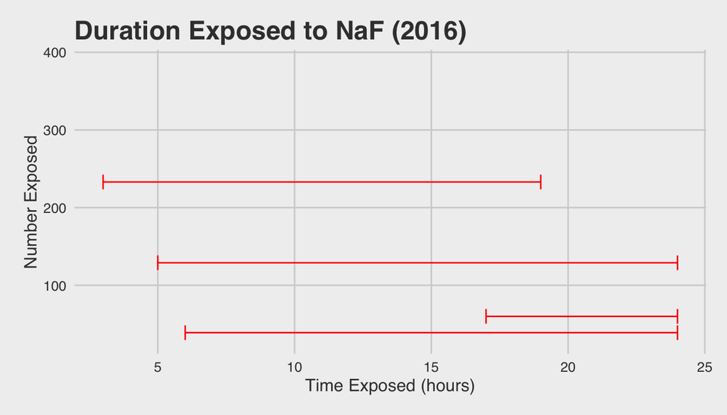

Note: *Because the control embryos weren’t exposed, and thus had no interval of exposure, they’ve been omitted from the above plot (n= 376).*

The variable being observed in both these datasets is the number of “arms” that developed. Under normal developmental circumstances embryos develop two arms, but exposure to NaF is believed to reduce the number of arms that develop.

For each group, the number of embryos with 0, 1, and 2 arms were counted and the total recorded.

# Results

## Results: Concentration of NaF

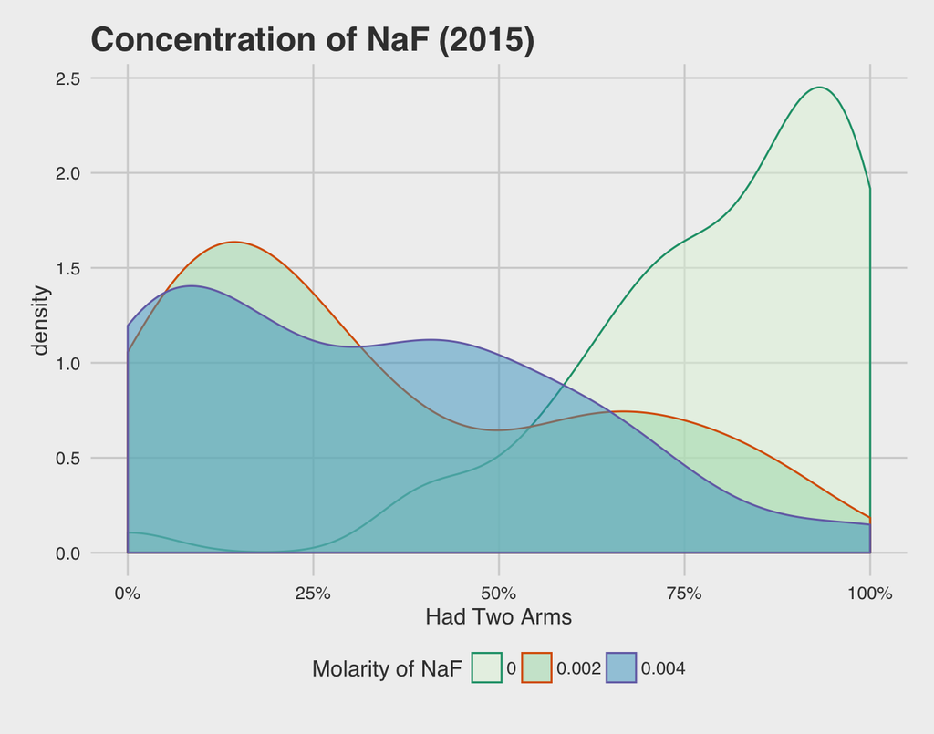

```r
Plot1 <- import("Data/2015.csv") %>%
  ggplot(aes(x=Arms2/Total, fill=factor(MolarityNaF),
             color=factor(MolarityNaF))) +
  geom_density(alpha=0.5) +
  labs(x="Had Two Arms") +
  scale_fill_brewer(name="Molarity of NaF", palette = 4) +
  scale_color_brewer(name="Molarity of NaF", palette = 2, type = "qual") +
  scale_x_continuous(labels = percent) +
  theme_fivethirtyeight() + theme(axis.title=element_text())
```

Unsurprisingly, the embryos exposed to NaF had a leftward skew, indicating a good number of embryos didn’t develop to have two arms. More importantly, it appears that both levels of NaF exposure (2 mM and 4 mM) have similar density distributions. This indicates that the level of exposure isn’t nearly as important as wither or not embryos are exposed in the first place.

This same observation can be seen if we examine the within-group distribution for each NaF concentration. The bar plot below shows the relative percentage of embryos with 0, 1, or 2 arms for each treatment group. The percentages are nearly identical for both concentrations, but show a marked difference from the control group (represented by 0 mols/L of NaF).

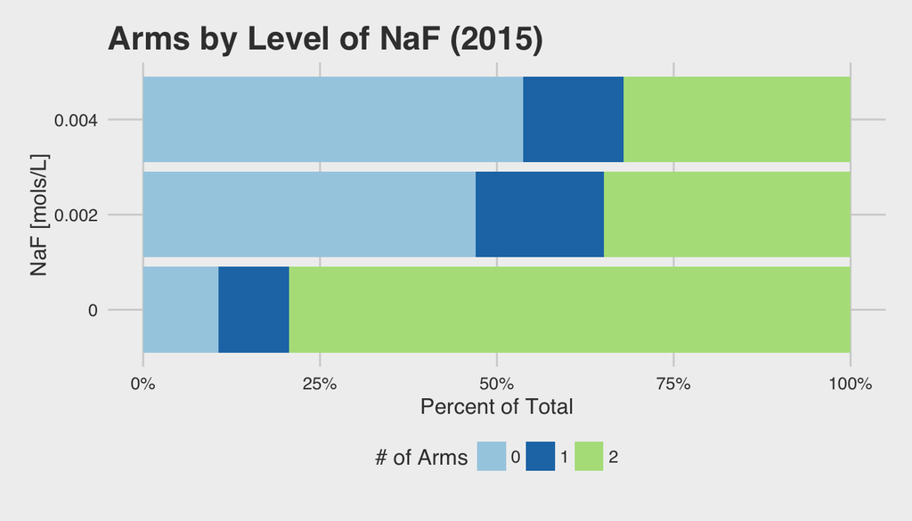

```r
df_15 %>%
  group_by(NaF=MolarityNaF, Treatment) %>%
  summarise(
    Total = sum(Total),
    Arms0 = sum(Arms0)/Total,
    Arms1 = sum(Arms1)/Total,
    Arms2 = sum(Arms2)/Total) %>%
  gather(Arms, Percent, Arms0:Arms2) %>%
  mutate(
    Arms = stringr::str_replace(Arms, "Arms", ""),
    Arms = paste(Arms, "Arms"),
    Percent = percent(Percent)) %>%
  spread(Arms, Percent) %>%
  select(-Treatment, -Total) %>%
  knitr::kable()
```

| NaF | 0 Arms | 1 Arms | 2 Arms |
| --- | --- | --- | --- |
| 0.000 | 10.6% | 10.0% | 79.4% |
| 0.002 | 47.0% | 18.1% | 34.9% |
| 0.004 | 53.7% | 14.2% | 32.1% |

## Results: Onset & Duration of Exposure

Given that the concentration of NaF doesn’t seem to be that important, the next logical question becomes about the timing of exposure. To explore this in more detail, we’ll take the same density plot that we discussed above, and facet it by each time interval of exposure:

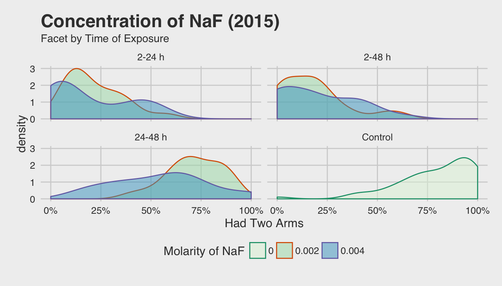

From this we can conclude that early exposure is a key component in disrupting arm development. Likewise, we see that these new density distributions hold true to our findings regarding the insignificance of the concentration of NaF.

Again, this can also be illustrated using bar plots:

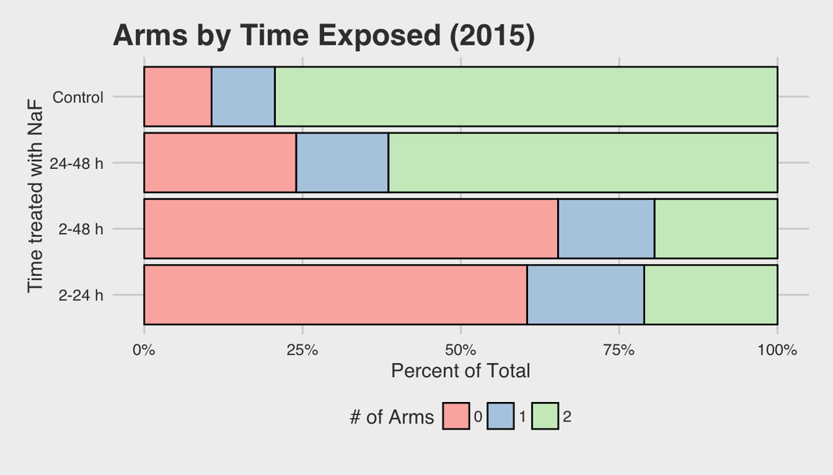

Next, we’ll take a look at the 2016 data. As mentioned above, this dataset takes a deeper look into the timing of exposure in the first 24 hours of development.

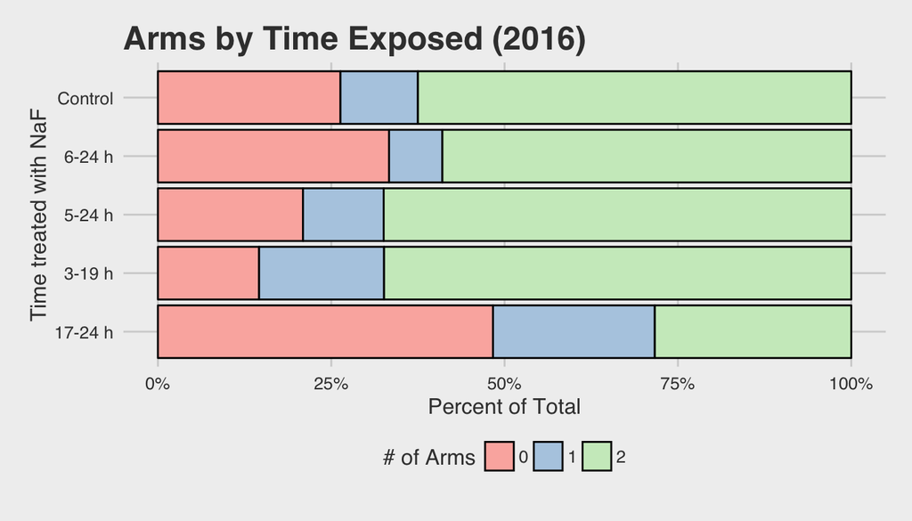

[output not shown]

In the spirit of [Reproducible Research](https://cran.r-project.org/web/views/ReproducibleResearch.html), below is the information About the R Session at the time it was compiled:

```r
devtools::session_info()
## Session info --------------------------------------------------------------
##  setting  value
##  version  R version 3.2.3 (2015-12-10)
##  system   x86_64, darwin14.5.0
##  ui       X11
##  language (EN)
##  collate  en_US.UTF-8
##  tz       America/Chicago
##  date     2016-04-05
## Packages ------------------------------------------------------------------
##  package      * version  date       source
##  assertthat     0.1      2013-12-06 CRAN (R 3.2.0)
##  chron          2.3-47   2015-06-24 CRAN (R 3.2.0)
##  colorspace     1.2-6    2015-03-11 CRAN (R 3.2.0)
##  curl           0.9.4    2015-11-20 CRAN (R 3.2.2)
##  data.table     1.9.6    2015-09-19 CRAN (R 3.2.0)
##  DBI            0.3.1    2014-09-24 CRAN (R 3.2.0)
##  devtools       1.10.0   2016-01-23 CRAN (R 3.2.3)
##  digest         0.6.8    2014-12-31 CRAN (R 3.2.0)
##  dplyr        * 0.4.3    2015-09-01 CRAN (R 3.2.0)
##  evaluate       0.8      2015-09-18 CRAN (R 3.2.0)
##  foreign        0.8-66   2015-08-19 CRAN (R 3.2.3)
##  formatR        1.2.1    2015-09-18 CRAN (R 3.2.0)
##  ggplot2      * 2.1.0    2016-03-24 Github (hadley/ggplot2@59c503b)
##  ggthemes     * 3.0.1    2016-01-10 CRAN (R 3.2.3)
##  gtable         0.1.2    2012-12-05 CRAN (R 3.2.0)
##  haven          0.2.0    2015-04-09 CRAN (R 3.2.0)
##  highr          0.5.1    2015-09-18 CRAN (R 3.2.0)
##  htmltools      0.3      2015-12-29 CRAN (R 3.2.3)
##  jsonlite       0.9.19   2015-11-28 CRAN (R 3.2.2)
##  knitr          1.12.3   2016-01-22 CRAN (R 3.2.3)
##  labeling       0.3      2014-08-23 CRAN (R 3.2.0)
##  lazyeval       0.1.10   2015-01-02 CRAN (R 3.2.0)
##  magrittr       1.5      2014-11-22 CRAN (R 3.2.0)
##  memoise        1.0.0    2016-01-29 CRAN (R 3.2.3)
##  munsell        0.4.2    2013-07-11 CRAN (R 3.2.0)
##  openxlsx       3.0.0    2015-07-03 CRAN (R 3.2.0)
##  plyr           1.8.3    2015-06-12 CRAN (R 3.2.0)
##  R6             2.1.1    2015-08-19 CRAN (R 3.2.0)
##  RColorBrewer   1.1-2    2014-12-07 CRAN (R 3.2.0)
##  Rcpp           0.12.2   2015-11-15 CRAN (R 3.2.2)
##  readODS        1.4      2014-07-07 CRAN (R 3.2.0)
##  readxl         0.1.0    2015-04-14 CRAN (R 3.2.0)
##  rio          * 0.2      2015-05-07 CRAN (R 3.2.0)
##  rmarkdown      0.9.1    2015-12-31 CRAN (R 3.2.3)
##  scales       * 0.3.0    2015-08-25 CRAN (R 3.2.0)
##  stringi        1.0-1    2015-10-22 CRAN (R 3.2.0)
##  stringr        1.0.0    2015-04-30 CRAN (R 3.2.0)
##  tidyr        * 0.4.1    2016-02-05 CRAN (R 3.2.3)
##  XML            3.98-1.3 2015-06-30 CRAN (R 3.2.0)
##  yaml           2.1.13   2014-06-12 CRAN (R 3.2.0)
```